# HW1_exer2

Group 9: Ana Gabriela Itokazu, Cary Burdick, Harsha Galkanda-Arachchige

September 18, 2020

# Exercise 2: Financial Analysis

First things first,

```r
if (!require("quantmod")) {
    install.packages("quantmod")
    library(quantmod)
}
```

Then, we need to fetch the data. This data set from four companies will obtained from Yahoo, from January 1-2019 to today’s date. This is done utilizing the package `quantmod`:

```r
start <- as.Date("2019-01-01")
end <- as.Date(Sys.Date())

getSymbols(c("VALE", "CSCO", "INTC", "WFC"),
           src="yahoo",
           from=start,
           to=end)
```

After that, the data sets should be fetched and can be seen in the environment tab. The first and last lines for the `VALE` dataset, for example:

|  | Open | High | Low | Close | Volume | Adjusted |
| --- | --- | --- | --- | --- | --- | --- |
| 2019-01-02 | 12.94 | 13.48 | 12.92 | 13.47 | 22120700 | 13.12351 |
| 2020-09-17 | 11.40 | 11.94 | 11.39 | 11.88 | 34145400 | 11.88000 |

We can create an `xts` object called `stocks` to unify all closing values from all the datasets (this `eXtensible Time Series` object will be used in several steps of this exercise). Then we can use the `plot()` function to take a look on it, and add a good-looking legend using the `addLegend()` function:

```r
stocks <- as.xts(data.frame(VALE=VALE[, "VALE.Close"],
                            CSCO=CSCO[, "CSCO.Close"],
                            INTC=INTC[, "INTC.Close"],
                            WFC=WFC[, "WFC.Close"]
                            ))
```

```r
plot(stocks,
     screens=1,
     lty=1:4,
     xlab="Date",
     ylab="Price",
     font.axis=1)
```

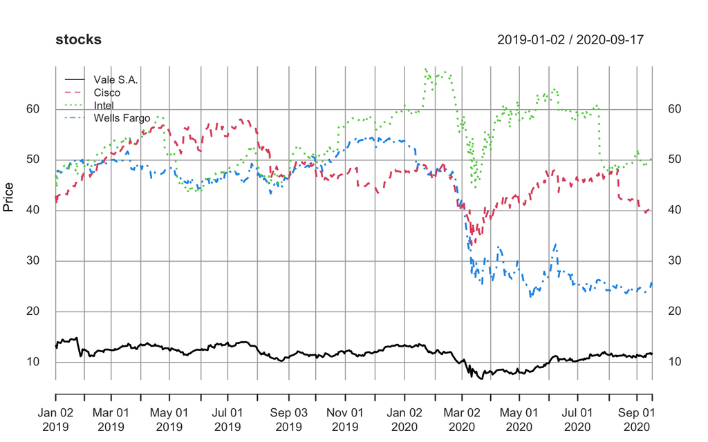

```r
addLegend(legend.loc = "topleft",
          legend.names = c("Vale S.A.", "Cisco", "Intel", "Wells Fargo"),
          lty= 1:4,
          col = NULL,
          ncol = 1,
          cex = 0.8,
          on = 1)
```

From the graph, we can see that the closing price of Vale S.A. is much lower than that of Cisco, Intel, and Wells Fargo throughout the year. It’s also very easy to see the sharp decline in the closing price of each stock in early March of 2020 indicating the start of the COVID-19 recession. Vale S.A.’s price began increasing again in May and has been steadily climbing, though it has not reached its pre-COVID price as of yet. Intel and Cisco showed signs of recovery after March with increasing prices, but both took another dip in price in July and August, respectively. Wells Fargo has shown almost no signs of recovery with its stock price sitting at about half the price of what it was before the initial hit in March.

We can also plot a Candle Chart of the four stocks over the last four months using the `candleChart()` function over a newly made `xts` object called `FinancialAnalysis`, which includes the values for all four stocks over the last 4 months:

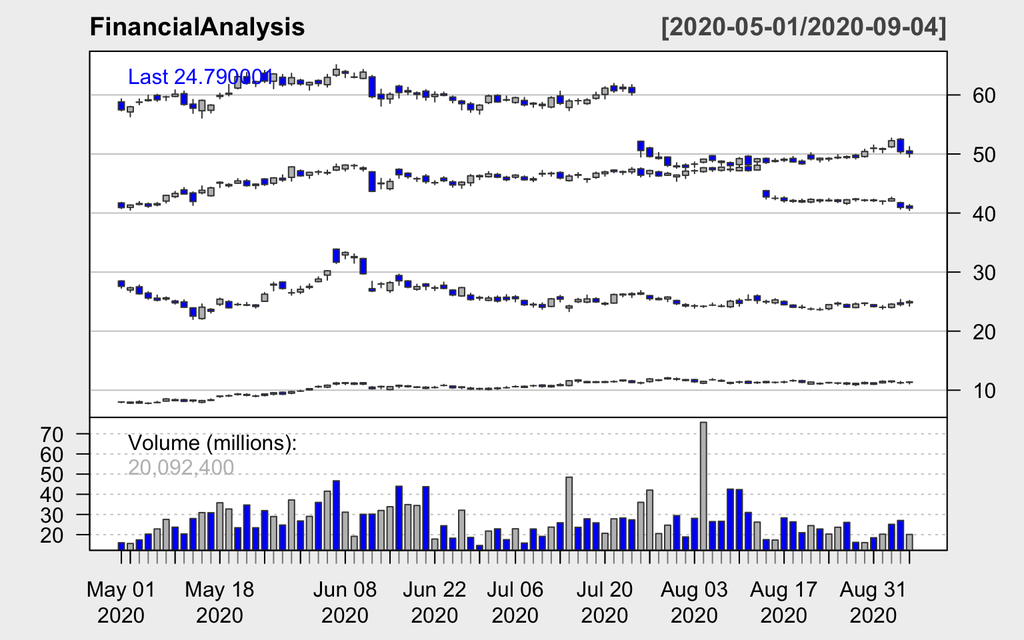

Figure 2. Candlestick chart of the four stocks over the past four months.

```r
# Redefining the data range and the data object

FinancialAnalysis <- as.xts(data.frame(VALE=VALE['2020-05-01/2020-09-06'],
                                       CSCO=CSCO['2020-05-01/2020-09-06'],
                                       INTC=INTC['2020-05-01/2020-09-06'],
                                       WFC=WFC['2020-05-01/2020-09-06']
))

# Calling the plot and making it nicer with some colours
candleChart(FinancialAnalysis,
            up.col="gray",
            dn.col="blue",
            theme="white")
```

In this type of graph, each day is represented by a “candle” which appears to be similar to a box plot, but the anatomy of a candle is slightly different.

**Wicks:** First, the lines or “wicks” sticking out of the top and bottom represent the high and low price of the stock. The top wick represents the highest price reached for the day while the bottom wick represents the lowest price reached.

**Color:** The color of the box represents if the price increased or decreased from the beginning to the end of the day. Gray boxes represent an overall increase for the day while blue boxes represent a decrease.

Coming back to that `stocks` object, we compute the mean and variance:

```r
#applying the Mean and Variance functions with a vector output into a data.frame object
stocks_stats <- cbind(data.frame(sapply(stocks, mean)),
                      data.frame(sapply(stocks, var)))

#making it prettier/intelligible
colnames(stocks_stats) <- c("Mean", "Variance")
rownames(stocks_stats) <- c("Vale S.A.", "Cisco", "Intel", "Wells Fargo")
```

|  | Mean | Variance |
| --- | --- | --- |
| Vale S.A. | 11.60951 | 2.826351 |
| Cisco | 47.83775 | 27.075166 |
| Intel | 53.83509 | 33.920287 |
| Wells Fargo | 41.75155 | 112.746153 |

Next, we want to compare these 4 stocks by their yearly Sharpe ratio $S$ based on the last 10 years, with an yearly risk-free rate of return $Rf$ is of $3.00\:\%$: First we need to fetch the data for the last 10 years.

```r
start <- as.Date("2010-09-01") #because I'm dumb
end <- as.Date(Sys.Date())

getSymbols(c("VALE", "CSCO", "INTC", "WFC"),
           src="yahoo",
           from=start,
           to=end)
```

Now.. Math!

Consider that the daily Sharpe Ratio is related to the yearly Sharpe Ratio by

$$\tilde{S} = \frac{S}{\sqrt{252}}$$

for which $\tilde{S}$ is defined as

$$\tilde{S} = \frac{\mathbb{E}[R_t - \tilde{R}_f]}{\sigma_{\mu}}$$

where:

- $\tilde{S}$ is the daily Sharpe ratio;
- $\mathbb{E}[\cdot]$ stands for the expected value (estimated by the mean);
- $R_t$ is the asset return defined as $R_t = \frac{X_t - X_{t-1}}{X_{t-1}}$ where $X_t$ is the price of an asset at time $t$;
- $\tilde{R}_f$ is the daily risk-free rate of return defined as $\tilde{R}_f = \frac{R_f}{252}$; and
- $\sigma_{\mu}$ is the standard deviation of the asset return.

Then, we calculate (all) this for each Company, breaking down the equations and each term to be more understandable:

```r
# assign common variables
Rf <- 3/100
Rf_ <- Rf/252

# Assign specific variables (see text full equations)
AssetReturnVALE <- dailyReturn(VALE)
stdVALE <- sd(AssetReturnVALE)
meanVALE <- mean(AssetReturnVALE)

AssetReturnCSCO <- dailyReturn(CSCO)
stdCSCO <- sd(AssetReturnCSCO)
meanCSCO <- mean(AssetReturnCSCO)

AssetReturnINTC <- dailyReturn(INTC)
stdINTC <- sd(AssetReturnINTC)
meanINTC <- mean(AssetReturnINTC)

AssetReturnWFC <- dailyReturn(WFC)
stdWFC <- sd(AssetReturnWFC)
meanWFC <- mean(AssetReturnWFC)

# Calculating Yearly Sharpe Ratio based on Daily Sharpe Ratio:

# Vale S.A.
S_VALE <- (meanVALE - Rf_)/stdVALE
SharpeVALE <- S_VALE * sqrt(252)

# Cisco
S_CSCO <- (meanCSCO - Rf_)/stdCSCO
SharpeCSCO <- S_CSCO * sqrt(252)

# Intel
S_INTC <- (meanINTC - Rf_)/stdINTC
SharpeINTC <- S_INTC * sqrt(252)

# Wells Fargo
S_WFC <- (meanWFC - Rf_)/stdWFC
SharpeWFC <- S_WFC * sqrt(252)
```

For which we could make a cleaner code, with the same results:

```r
SharpeVALE2 <- ((mean(dailyReturn(VALE))-(0.03/252))
                / sd(dailyReturn(VALE))) * sqrt(252)

SharpeCSCO2 <- ((mean(dailyReturn(CSCO))-(0.03/252))
                / sd(dailyReturn(CSCO))) * sqrt(252)

SharpeINTC2 <- ((mean(dailyReturn(INTC))-(0.03/252))
                / sd(dailyReturn(INTC))) * sqrt(252)

SharpeWFC2 <- ((mean(dailyReturn(WFC))-(0.03/252))
               / sd(dailyReturn(WFC))) * sqrt(252)
```

ta-da!

| Company | Calculated Sharpe Ratio | the other Calculated Sharpe Ratio |
| --- | --- | --- |
| Vale S.A. | -0.0061979 | -0.0061979 |
| Cisco | 0.2774342 | 0.2774342 |
| Intel | 0.3993498 | 0.3993498 |
| Wells Fargo | 0.0561231 | 0.0561231 |

The Sharpe ratio is helpful in understanding the risk vs. reward of a certain stock portfolio. It takes into account the average return earned in excess of the risk-free rate (which in this case is 3%) with respect to units of volatility. The risk-free rate is a simple way of saying that investing in something with zero risk will yield a 3% return on investment (ROI). According to Hargrave (2020), the higher the Sharpe ratio, the more attractive the stock is in terms of the risk adjusted reward. However, we are now taking the yearly Sharpe ratio of these four stocks from the past 10 years, so the information just received from the past four months cannot be compared directly.

It appears that Intel has the highest Sharpe ratio of the four stocks, meaning over the past 10 years it has yielded the best risk-adjusted performance. It is crucial to reiterate that this is risk-adjusted performance and not necessarily pure ROI. A stock can provide a very high return, but it may also come with very high risk and volatility, which would lower its Sharpe ratio. This is to say that Intel didn’t necessarily provide higher returns than the other three stocks, but it can help explain that its returns are due to smarter, less volatile investments. Additionally, a negative Sharpe ratio, as observed by Vale S.A., can either mean one of two things: the return will be negative, or the chosen risk-free rate is greater than the return of the stock itself. Either way, its a good indication to invest your money elsewhere.

Now we consider consider an equally weighted portfolio of all of these stocks combined. We simply add each of the four stocks together per day, then take the average to calculate the equally weighted new stock. Below are the four stocks listed again with the “Combined” stock at the bottom for comparison:

```r
stocks2 <- as.xts(data.frame(VALE=dailyReturn(VALE),
                            CSCO=dailyReturn(CSCO),
                            INTC=dailyReturn(INTC),
                            WFC=dailyReturn(WFC)
                            ))

#creating a combined row with the averages for all companies
stocks2$Totals <- rowSums(stocks2)/4

stocks_combined <- cbind(data.frame(sapply(stocks2, mean)),
                         data.frame(sapply(stocks2, var)))

colnames(stocks_combined) <- c("Mean", "Variance")
rownames(stocks_combined) <- c("Vale S.A.", "Cisco", "Intel", "Wells Fargo", "Combined")
```

|  | Mean | Variance |
| --- | --- | --- |
| Vale S.A. | 0.0001075 | 0.0008811 |
| Cisco | 0.0004164 | 0.0002895 |
| Intel | 0.0005666 | 0.0003165 |
| Wells Fargo | 0.0001829 | 0.0003260 |
| Combined | 0.0003183 | 0.0002462 |

Since they were equally weighted, the mean return of the Combined stock is just an average of the averages. So it would have a middle-of-the-road return, but with the lowest variance, it would also have the most predictable and least volatile return on average.

### References

Duberstein, Billy. 2020. “Why Intel Dropped 20.2.” Available at fool.com/investing/2020/08/05/why-intel-dropped-202-in-july.aspx (2020/09/16).

Hargrave, Marshall. 2020. “Sharpe Ratio.” Available at https://www.investopedia.com/terms/s/sharperatio.asp (2020/09/16).